# BIOST 561: function design

Lecture 4

# An example about mutate

- `summarize()`/`summarise()` creates a new tibble that computes one number from a vector (“column”) of variables
- `mutate()` creates a new variable (“column”, one value per row) based on the other existing variables

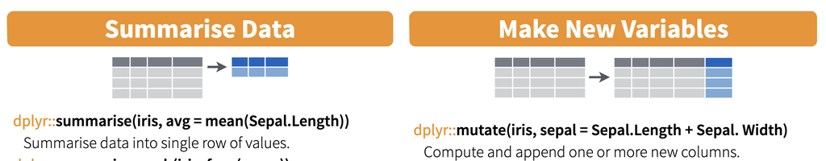

See also https://www.washstat.org/seminars/2015/20150428_datascience_docs/data-wrangling-cheatsheet.pdf

To see an example, recall our COVID dataset.

```r
library(medicaldata)
covid_testing
```

```
## # A tibble: 15,524 × 17
##    subject_id fake_first_name fake_last_name gender pan_day test_id clinic_name
##         <dbl> <chr>           <chr>          <chr>    <dbl> <chr>   <chr>
##  1       1412 jhezane         westerling     female       4 covid   inpatient w…
##  2        533 penny           targaryen      female       7 covid   clinical lab
##  3       9134 grunt           rivers         male         7 covid   clinical lab
##  4       8518 melisandre      swyft          female       8 covid   clinical lab
##  5       8967 rolley          karstark       male         8 covid   emergency d…
##  6      11048 megga           karstark       female       8 covid   oncology da…
##  7        663 ithoke          targaryen      male         9 covid   clinical lab
##  8       2158 ravella         frey           female       9 covid   emergency d…
##  9       3794 styr            tyrell         male         9 covid   clinical lab
## 10       4706 wynafryd        seaworth       male         9 covid   clinical lab
## # ℹ 15,514 more rows
## # ℹ 10 more variables: result <chr>, demo_group <chr>, age <dbl>,
## #   drive_thru_ind <dbl>, ct_result <dbl>, orderset <dbl>, payor_group <chr>,
## #   patient_class <chr>, col_rec_tat <dbl>, rec_ver_tat <dbl>
```

```
covid_testing %>%
  mutate(full_name = paste(fake_first_name, fake_last_name)) %>%
  select(fake_first_name, fake_last_name, full_name)
```

# Last bit about tibbles

- From https://tavareshugo.github.io/r-intro-tidyverse-gapminder/09-reshaping/index.html

- To switch from one format to another, you use the `pivot_wider()` and `pivot_longer()` functions in the `tidyr` package.


# Now, how exactly are R packages organized?

- Let’s take a look at the example package for our course, https://github.com/linnykos/561_s2026_example

# The `DESCRIPTION` file

The `DESCRIPTION` file serves three puposes:

```
Package: UWBiost561
Type: Package
Title: Example package of UW BIOST 561 S2026
Version: 0.1.0
Author: Kevin Lin
Maintainer: Kevin Lin <kzlin@uw.edu>
Description: Describing the EM algorithm for spherical Gaussians.
License: MIT +file LICENSE
Encoding: UTF-8
LazyData: true
RoxygenNote: 7.3.3
URL: https://linnykos.github.io/561_s2025_example/, https://linnykos.github.io/561_s2026_example/
VignetteBuilder: knitr
Imports:
    dplyr,
    magrittr,
    MASS,
    mvtnorm,
    tibble
Suggests:
    testthat, knitr, markdown
```

If we take a look at the `glmnet` package (to fit a LASSO regression, see https://cran.r-project.org/web/packages/glmnet/index.html):

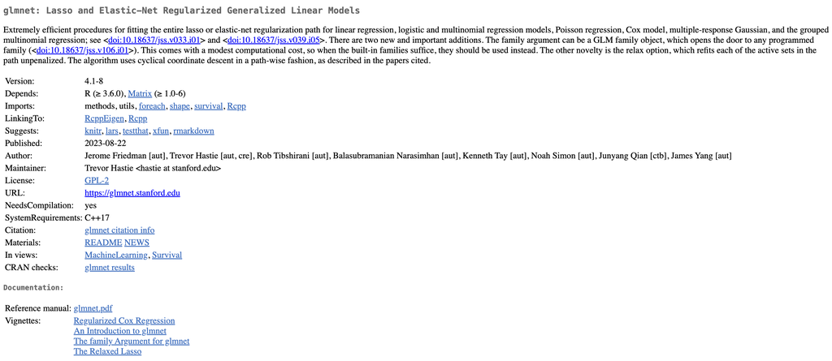

This file is the literally in https://github.com/cran/glmnet/blob/master/DESCRIPTION.

[figure not shown]

# The `R` folder

- This folder contains all the custom R functions (i.e., all the functions you write).
- See https://github.com/cran/glmnet/tree/master/R for an example

[figure not shown]

- For example, if we look at `rmult.R`:

[figure not shown]

# Documenting a function via `ROxygen`

- In the screenshot for `rmult.R`, you see a lot of other lines before the literal function definition in line 12. What is all this stuff?
- In R, try the following in your console

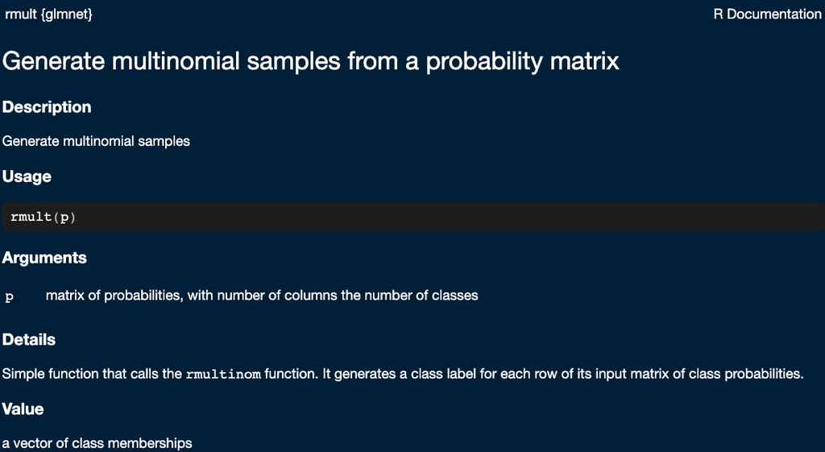

```r
# run after installing the glmnet package!
library(glmnet)
?glmnet::rmult
```

This is the documentation for the `glmnet::rmult` function.

If you look at what the lines of code starting with the `#'` characters in https://github.com/cran/glmnet/blob/master/R/rmult.R (i.e., lines 1 through 11), you’ll notice it looks strikingly similar to the documentation.

```
#' Generate multinomial samples from a probability matrix
#'
#' Generate multinomial samples
#'
#' Simple function that calls the \code{rmultinom} function. It generates a class label
#' for each row of its input matrix of class probabilities.
#'
#' @param p matrix of probabilities, with number of columns the number of classes
#' @return a vector of class memberships
#' @author Trevor Hastie \cr Maintainer: Trevor Hastie <hastie@@stanford.edu>
#' @export rmult
```

This is because R somehow knew to convert these lines of code into the documentation! This is what ROxygen does – You write the documentation “in-line” with the code, and then R Studio does something magical (which we’ll discuss in a bit) that “converts” this text into a documentation.

# What does `@export` mean?

- Your R package will include a lot of functions
- Many of them will **not** be functions you expect anyone else except you to know about
  - These are “helper” functions. More on this later today!
- Functions that are not “exported” will not have documentation for
  - Users (not you) who install the package will not even know non-exported function exist!
- Take a look at this example:
  - When I design a function called `cleanup_na_matrix()`, I **do expect** people who use my package might want to use this function.
  - However, internally, this function uses `.cleanup_na_vector()`, which I do **not expect** people will use, so I do not “export” it.

```
#' Clean-up all NAs in a matrix
#'
#' Replace all the NAs in each column with the median value of non-NAs
#' (or all 0's if all values are NAs).
#'
#' @param mat a numeric matrix
#'
#' @return a numeric matrix without NAs
#' @export
cleanup_na_matrix <- function(mat){
  stopifnot(is.matrix(mat), all(is.numeric(mat)))

  n <- nrow(mat)
  p <- ncol(mat)
  mat <- sapply(1:p, function(j){
    .cleanup_vector(mat[,j])
  })

  return(mat)
}

.cleanup_na_vector <- function(vec){
  n <- length(vec)
  idx <- which(is.na(vec))
  if(length(idx) == n) vec <- rep(0, n)
  if(length(idx) > 0){
    vec[idx] <- stats::median(vec, na.rm = TRUE)
  }

  return(vec)
}
```

# The impact of exporting functions

- For `glmnet`, if you look at https://cran.r-project.org/web/packages/glmnet/glmnet.pdf, you’ll see the documentation for all the functions

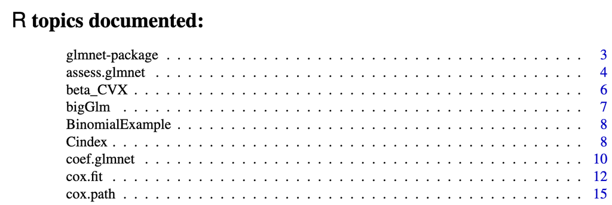

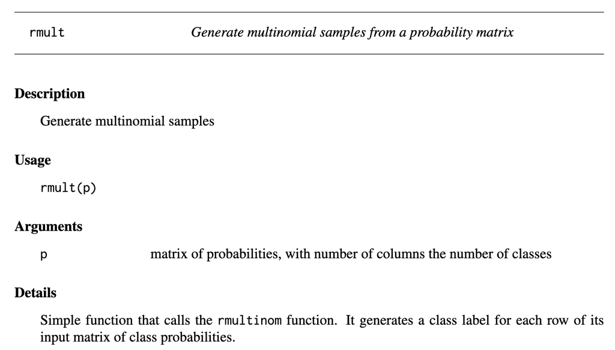

- How did R know which functions to put in this list?
  - The answer: All the functions that the author put the `@export` tag for!

# So that’s what’s in the `man` folder (short for “manual”)

- All these “intermediary” files (suffix: `.Rd`) are what’s in the `man` folder.
- In general, you will never need to directly modify/touch any file in the `man` folder.
  - Once I tell you how to create the documentation for an R package, you’ll see that all these files are automatically generated.
  - You’ll see the line `% Generated by roxygen2: do not edit by hand` in the `rmult.Rd` file.

[figure not shown]

[figure not shown]

# So… how do I use this ROxygen thing myself?

The pipeline (which we will talk in more detail later in course) is:

1. Write your function in a `.R` file under the `R` folder in your package

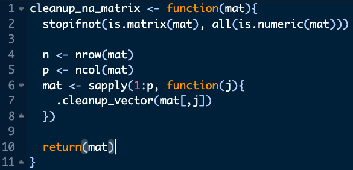

2. When your text editor cursor (i.e., where you type) is inside your function, navigate to “Code” -> “Insert Roxygen skeleton”

[figure not shown]

3. R Studio will auto-populate some simple things into your text editor above your function

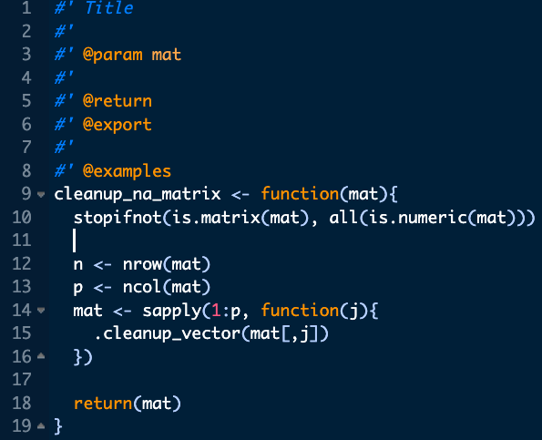

4. Then, you can write all the fields that you want.

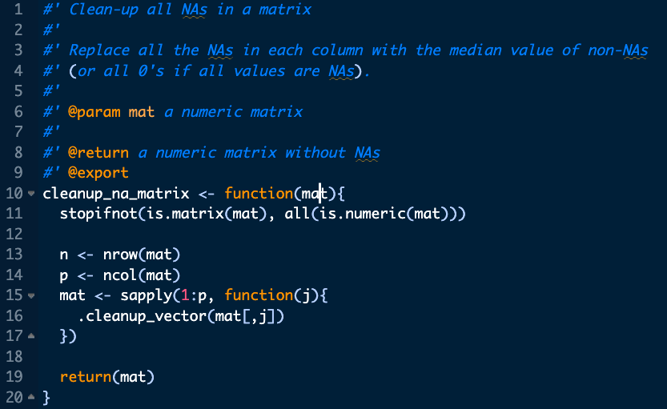

- How to convert this text into R documentation inside the `man` folder? See the next slide!
- See https://roxygen2.r-lib.org/articles/roxygen2.html for more details, and https://roxygen2.r-lib.org/articles/rd-formatting.html to how to format your Roxygen output.

# Creating all the files you’re looking for

After you do all this hard to write all these R functions and Roxygen documentation, how do all these other files get auto-generated?

Let’s use our `UW561S2024Example` package as an example. (This is the same as `UWBiost561` package, except from 2024.)

Let’s say our current R package looks like this:

[figure not shown]

Then, you can run `devtools::check()` in the R console (**not** in your R markdown file). Make sure you’re in your R project for this R package.

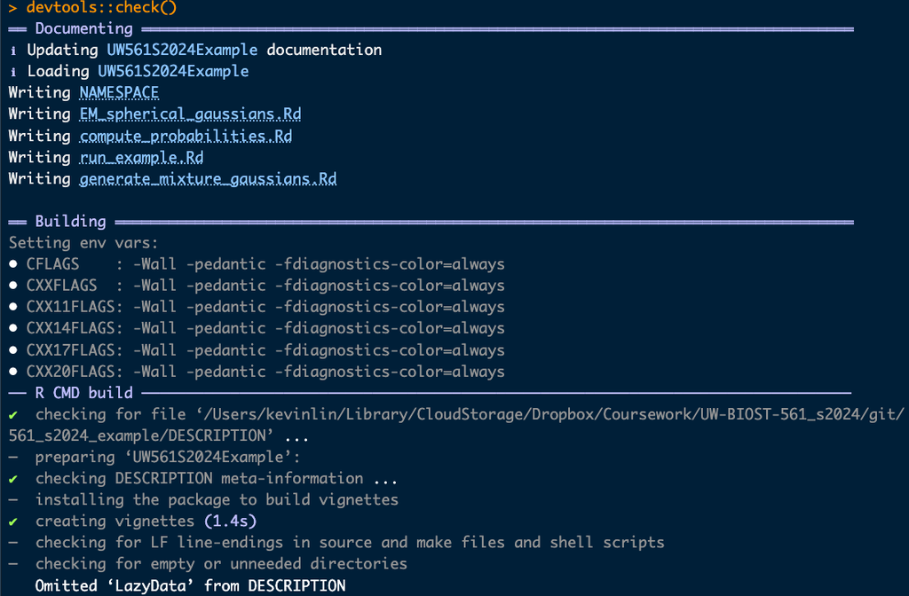

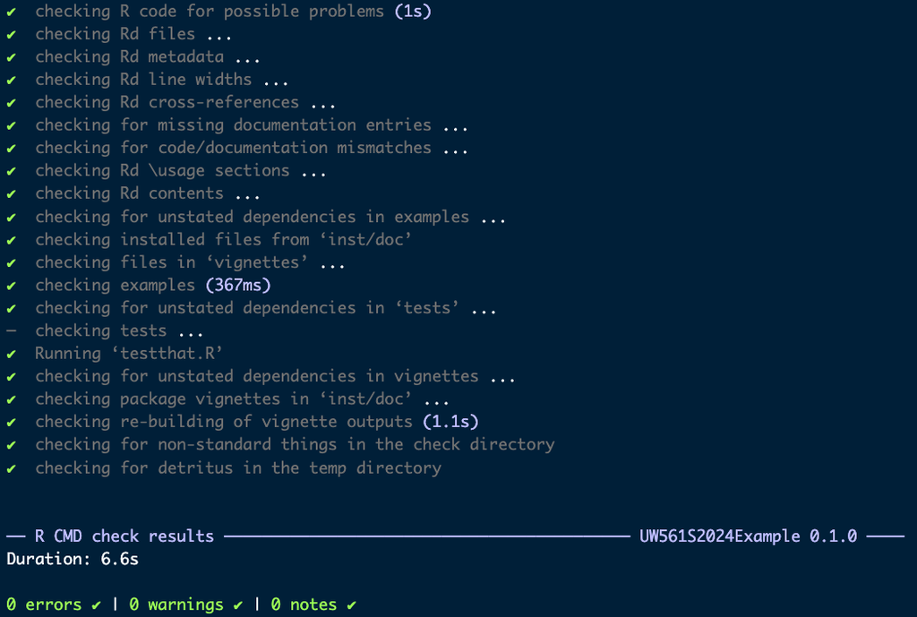

Afterwards, you’ll see all these new files inside your folder that we were expecting:

[figure not shown]

See more with `?devtools::check` to see how to you can change how the function works.

# Checking and installing a custom R package

`devtools::check()` actually does a **lot** of things (which we’ll talk more about later in the course).

- It prepares your files to become an R package
- It runs your tests to make sure your code works as intended. (More on this next week)
- It runs simple style-checks to make sure your code abides by CRAN standards
- It is **very painful** to fix your code to abide by CRAN standards after-the-fact. It’s **much easier** to write your code from the start that follows CRAN standards

After you’ve run `devtools::check()`, you can run `devtools::load_all()` to locally load all your functions in your `R` folder. (Alternatively, if you weren’t in your R project, you would need to run `devtools::install()` and then load your package via `library()` as if it were any other package.)

# Followup: The `NAMESPACE` file

The `NAMESPACE` file is an important file for R packages, but **you** will not need to create it yourself.

For example, if you look at the `NAMESPACE` for the `glmnet` function, it looks like this (from https://github.com/cran/glmnet/blob/master/NAMESPACE):

[figure not shown]

As you can see, it says `# Generated by roxygen2: do not edit by hand`. It is automatically generated when you run `devtools::document()`.

# Followup: The `.Rbuildignore` file and `.gitignore` file

- `.Rbuildignore` tells which files `devtools::check()` should ignore.
  - Strictly speaking, the only files in your R package should be **for** the R package.
  - You can circumvent this by including the excluded files in `.Rbuildignore`
- `.gitignore` tells which files Git should ignore when tracking changes

# So… Why do my vignettes not appear in the `vignettes` folder?

- R packages are designed to be as “lightweight” as possible
  - If you scroll down to “Package source” in https://cran.r-project.org/web/packages/glmnet/index.html, you can literally download the source code for the entire package if you want
- See the policy at https://cran.r-project.org/web/packages/policies.html

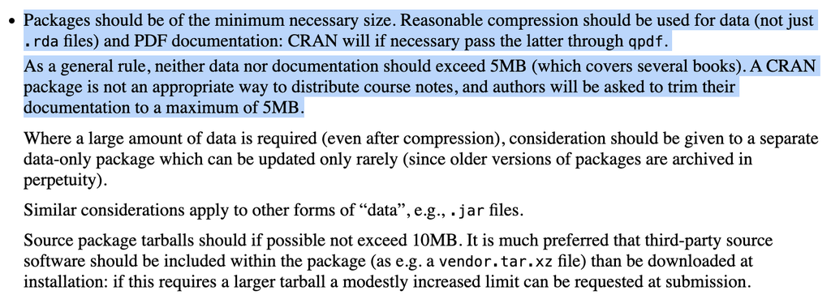

- For this reason, when you knit a vignette, it does **not** automatically put the updated HTML file inside the R package. See https://stackoverflow.com/questions/48774057/default-location-of-generated-html-file-using-knitr-and-rstudio-varies-strangely

# Break

We’ll do a graph exercise after break, since it’ll be useful for your HW2

# Exercise as a class

Suppose I’m given this matrix that encodes a graph:

```r
set.seed(10)
adj_mat <- matrix(stats::rbinom(n = 100,
                                size = 1,
                                prob = 0.25),
                  nrow = 10,
                  ncol = 10)
adj_mat <- adj_mat + t(adj_mat) #Symmeterize
adj_mat[adj_mat > 0] <- 1
diag(adj_mat) <- 0 #Remove self-edges
adj_mat
```

```
##       [,1] [,2] [,3] [,4] [,5] [,6] [,7] [,8] [,9] [,10]
##  [1,]    0    0    1    0    0    0    0    0    1     0
##  [2,]    0    0    0    0    0    1    0    0    0     1
##  [3,]    1    0    0    0    0    0    1    0    1     0
##  [4,]    0    0    0    0    0    0    1    1    0     0
##  [5,]    0    0    0    0    0    0    1    0    0     1
##  [6,]    0    1    0    0    0    0    1    0    0     1
##  [7,]    0    0    1    1    1    1    0    0    1     0
##  [8,]    0    0    0    1    0    0    0    0    0     0
##  [9,]    1    0    1    0    0    0    1    0    0     0
## [10,]    0    1    0    0    1    1    0    0    0     0
```

Write a script where, given this specific graph:

- Determine if the graph is connected (i.e., there is a way to go from any node to any other node)?

(By the way, this graph looks like this):

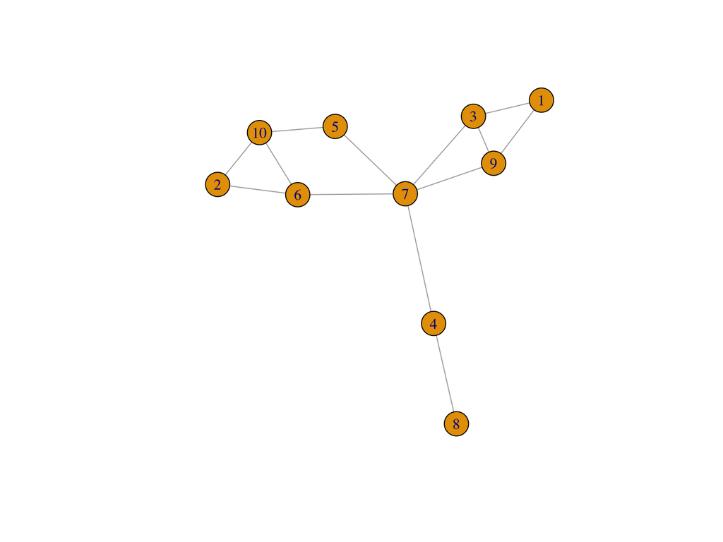

```r
g <- igraph::graph_from_adjacency_matrix(adj_mat,
                                         mode = "undirected")
plot(g)
```

# Now onto how to design R functions

Now that you have a high-level sense of how R packages works, the bigger question is: “How should I write my functions?”

- It’s one thing to write “code that works”
  - (this is the focus next week).
- It’s another thing to write “code that is easy to understand” and “code that makes it harder to accidentally introduce bugs”
  - (the rest of today’s lecture)

# In-class question: What is the benefit of having a style guide?

- Google’s R style guide: https://google.github.io/styleguide/Rguide.html, which comes from https://style.tidyverse.org/

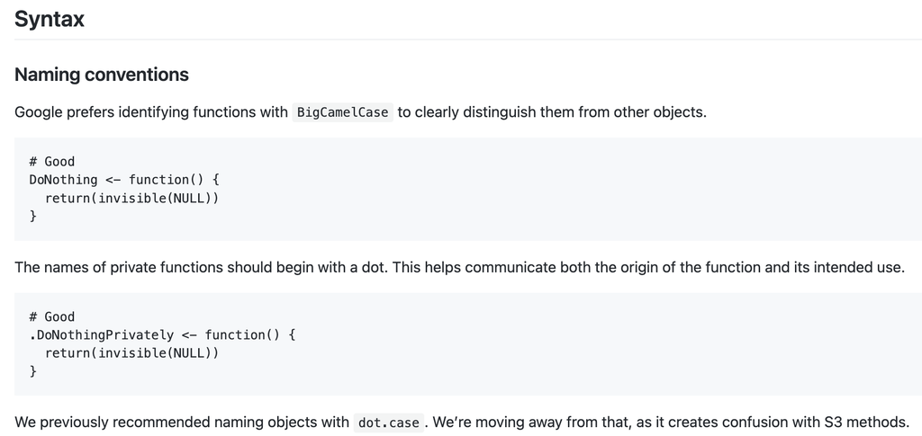

- (JK. Google doesn’t actually code a lot in R. It has a much more extensive style guide for Python: https://google.github.io/styleguide/pyguide.html)

# Summary of guiding principles

- Be careful about default values in your function.
  - There’s nothing wrong with them.
  - What’s concerning is when **you** change your default value half-way through your research project, and 6 months later, you forgot that this change happened
- Checking what you’re outputting
- “Public” vs. “Private” functions
- Prefixing function calls with which packages they’re from
- Being consistent with the order of your arguments
- Naming functions

# Default values

Default values, as the name suggests, are when an argument has a default value when it is not explicitly defined the function call.

```r
# A very simple (unnecessary) function that computes the quantile of a vector
demo_function <- function(x, quantile_value){
  stats::quantile(x, probs = quantile_value)
}
# Again, try to avoid having variables the same as function names
# (That is why I named the variable "quantile_value", not "quantile")

set.seed(0)
x <- stats::rnorm(100)
demo_function(x, quantile_value = 0.9)
```

```
##      90%
## 1.239882
```

If we knew that most of the time, we would be computing the 90% quantile, then we could set `quantile=0.9` directly.

```r
demo_function <- function(x, quantile_value = 0.9){
  stats::quantile(x, probs = quantile_value)
}

set.seed(0)
x <- stats::rnorm(100)
# no need to define the quantile!
demo_function(x)
```

```
##      90%
## 1.239882
```

```r
# we still have the flexibility to change this
demo_function(x, quantile_value = 0.5)
```

```
##         50%
## -0.03296148
```

Many functions you use day-to-day have many default values

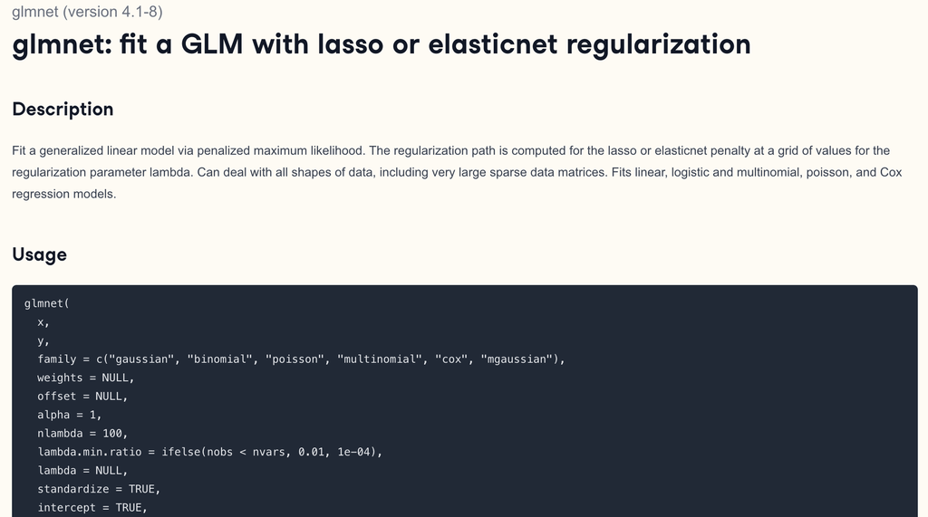

See https://www.rdocumentation.org/packages/stats/versions/3.6.2/topics/lm

# WARNING: There’s a price for convenience

Default values are great when you’re done with your project and am ready to release your codebase to the world (since it means other users need to worry about less arguments).

**HOWEVER:** While default values are convenient (i.e., you set them once, and never need to worry about them again), **SET DEFAULT VALUES TO YOUR FUNCTIONS SPARINGLY** while you’re working on your research project.

- If you’re working on a project today, and use default values to get a set of results
- 3 months from now, you realize (during your discussions with your advisor) that your method benefits from a different default argument
- 6 months from now, you get new results, but they don’t look as great as your old results
- 9 months from now, you use your new codebase to try to reproduce your results from 9 months ago (i.e., today). However, because you forgot you had changed your default values to your results, you cannot figure out why you cannot reproduce your results.

By avoiding using default values during your project’s development, you **force yourself** to declare **all** your arguments upfront, so you never are uncertain which arguments use which values.

(Yes: Your code will look uglier if you avoid setting default values. But also, yes, future-you will be grateful for this.)

# The output of functions

A few tips on how to return things in your functions:

- Be explicit about the return statement by using the `return()` function
- For 80% of the instances where your function needs to return multiple “things”, you probably want to return a **named** list. (More on this in a bit.)
- A few lines before the return statement, write some code to check if the things you are returning are roughly what you expect.
  - Mainly: Checking the class of each output (is your output that’s supposed to be a matrix really a matrix?), and checking the dimensions/lengths of the things you’re outputing

Unlike C++ and Java, functions in R do **not** check the class of the outputs.

- Just because your function “did not crash,” it **does not mean** your function is correct.
- Many “bugs” are introduced because your function successfully ran, but unbeknowst to you (until much later), most of the outputs were `NA` or `NaN`.

# “public” vs. “private” functions

You might’ve noticed that I sometimes put a `.` before the function argument. For example, the `.cleanup_na_vector()` function:

```
cleanup_na_matrix <- function(mat){
  stopifnot(is.matrix(mat), all(is.numeric(mat)))

  n <- nrow(mat)
  p <- ncol(mat)
  mat <- sapply(1:p, function(j){
    .cleanup_vector(mat[,j])
  })

  return(mat)
}

.cleanup_na_vector <- function(vec){
  n <- length(vec)
  idx <- which(is.na(vec))
  if(length(idx) == n) vec <- rep(0, n)
  if(length(idx) > 0){
    vec[idx] <- stats::median(vec, na.rm = TRUE)
  }

  return(vec)
}
```

Curiously enough, Google’s style-guide also mentioned this:

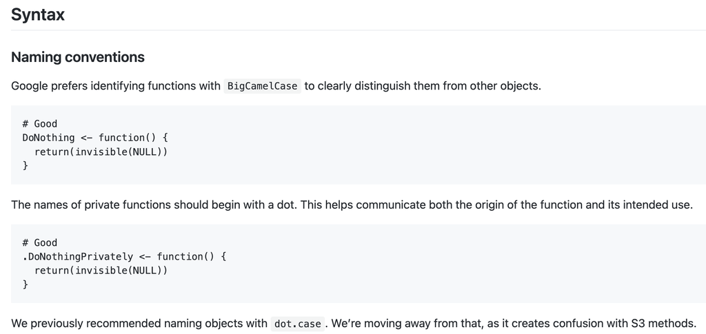

What on earth is this about?

When I run these lines of code, notice the `.cleanup_na_vector()` is “hidden” from the environment.

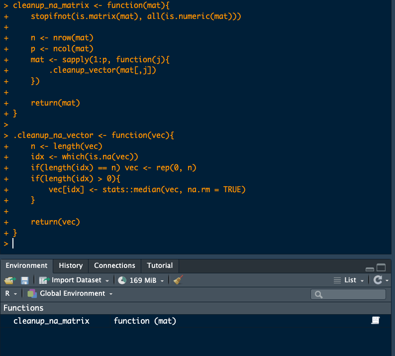

When you put a `.` in front of your function, you are making the **intent** of the function clear – this function is **NOT** meant for anyone else except the author (you) to use.

This is “weaker” (i.e., not as explicit) as not exporting your function via `@export` using Roxygen, but it has a similar effect.

- This coding practice is commonplace because you don’t usually write explicit documentation for code until **after** you’re done with the project.
- However, you want to make it clear to yourself that this function is intended to be “private” **while** you’re working on the project.

# Prefixing the functions inside your function

Another odd thing you might’ve realized is that I use `::` in my functions:

```
.cleanup_na_vector <- function(vec){
  n <- length(vec)
  idx <- which(is.na(vec))
  if(length(idx) == n) vec <- rep(0, n)
  if(length(idx) > 0){
    vec[idx] <- stats::median(vec, na.rm = TRUE)
  }

  return(vec)
}
```

Curiously, Google’s Style-guide also states this and explains why:

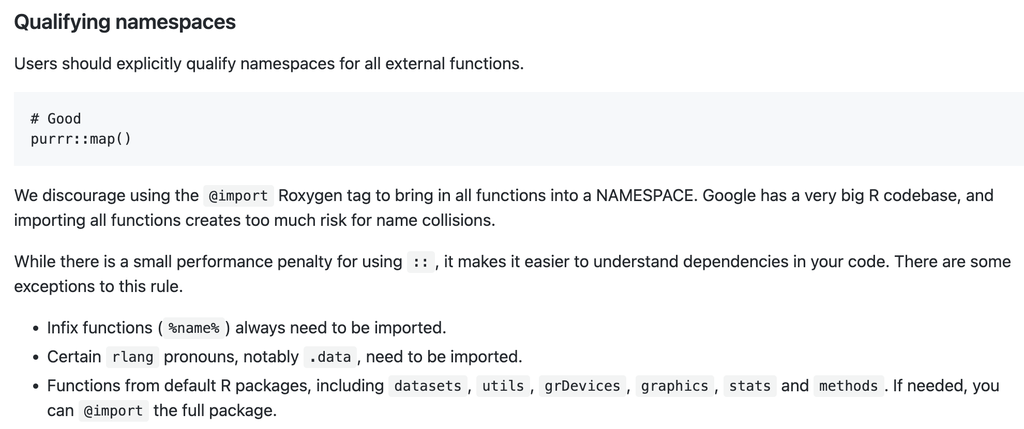

# Why should you prefix your function-calls with the package it’s from?

Reason 1: So someone else can understand your code. Take this example of my code from 2019:

```
clique_selection <- function(...){ # some arguments
  d <- vcount(g)
  adj <- as.matrix(as_adjacency_matrix(g))

  clique_list <- lapply(maximal.cliques(g), function(x){
    sort(as.numeric(x))
  })
  if(any(!is.na(target_idx))) {
    clique_list <- prune_clique(adj,
                                clique_list,
                                target_idx,
                                threshold)
  }
  if(length(clique_list) == 1) return(list(1:ncol(adj)))
  largest_clique <- list(sort(clique_list[[
    which.max(sapply(clique_list, length))
  ]]))

  len <- length(clique_list)
  queue <- initialize_queue(len)
  hash_history <- hash()
  hash_children <- initialize_children(clique_list)
  hash_unique <- initialize_unique(clique_list, d)

  # ... some more lines later on
}
```

If you saw this code for the first time, there are **so** many new functions, you might be very confused – which functions did Kevin write, and which functions did he use a package for?

Instead, if it were written as:

```
clique_selection <- function(...){ # some arguments
  d <- igraph::vcount(g)
  adj <- as.matrix(igraph::as_adjacency_matrix(g))

  clique_list <- lapply(igraph::maximal.cliques(g), function(x){
    sort(as.numeric(x))
  })
  if(any(!is.na(target_idx))) {
    clique_list <- prune_clique(adj,
                                clique_list,
                                target_idx,
                                threshold)
  }
  if(length(clique_list) == 1) return(list(1:ncol(adj)))
  largest_clique <- list(sort(clique_list[[
    which.max(sapply(clique_list, length))
  ]]))

  len <- length(clique_list)
  queue <- initialize_queue(len)
  hash_history <- hash::hash()
  hash_children <- initialize_children(clique_list)
  hash_unique <- initialize_unique(clique_list, d)

  # ... some more lines later on
}
```

Then you can be like, “Aha, I see, so I only need to worry about understanding all the function without a `::`, since those are the functions that Kevin must’ve defined somewhere.”

Reason 2: There might be a function name that used in **multiple** packages, and you want to make sure R uses the correct one.

Consider the example of compute the difference between extreme left-tail areas of a standard Gaussian. (We’re 29 standard deviations away from the mean!! These values are **tiny**)

```r
pnorm(-29) - pnorm(-29.1)
```

```
## [1] 3.110291e-185
```

```r
# this equivalent to:
stats::pnorm(-29) - stats::pnorm(-29.1)
```

```
## [1] 3.110291e-185
```

```r
# since the `pnorm` function is by default in the `stats` package
```

However, what if we specifically wanted to use the `pnorm` function in `Rmpfr` package (a package used for extreme scientific computing)?

```r
library(Rmpfr)
x1 <- Rmpfr::mpfr(29.1, precBits = 1000)
x2 <- Rmpfr::mpfr(29.0, precBits = 1000)

Rmpfr::pnorm(x1) - Rmpfr::pnorm(x2)
```

```
## 1 'mpfr' number of precision  1000   bits
## [1] 3.110290987043068327444744360586094561713861538270027843988274…-185
```

```r
# (I wouldn't try running this code yourself.
# This code is just to showcase!)
```

# The order of your arguments

- When you’re coding, you usually have a habit of putting “the more important arguments” in the front.

```r
compute_snns <- function(input_obj,
                         latent_k,
                         num_neigh,
                         bool_cosine = TRUE,
                         bool_intersect = TRUE,
                         min_deg = 1,
                         tol = 1e-4,
                         verbose = 0){
  # ...
}
```

There’s a sense that the input object (`input_obj`) is the “most important” argument, hence it’s first.

This personal heuristic is great for exported functions (i.e., “public” functions you expect other people to use), since it’ll make their life easier.

**HOWEVER:** For “private” functions (i.e., functions you name with a `.` in front, that you don’t expect other people to use), it is **very** easy to make a coding error by forgetting what the literal order of arguments is.

- What you think is the most “obvious” order of arguments might not be what you think in 6 months!

A **very** common way to introduce bugs is that you passed in the arguments in wrong order!!

Here are the rules I follow (whenever I remember) for “private” functions:

- Order all the arguments by alphabetic order. (That way, there’s no abiguity. More on this in a bit.)

```r
.tiltedCCA_common_score <- function(averaging_mat,
                                    cca_res,
                                    discretization_gridsize,
                                    enforce_boundary,
                                    fix_tilt_perc,
                                    snn_bool_cosine,
                                    snn_bool_intersect,
                                    snn_k,
                                    snn_min_deg,
                                    snn_num_neigh,
                                    svd_1,
                                    svd_2,
                                    target_dimred,
                                    verbose = 0){
  # ...
}
```

- When you use your private function, literally write out the argument name.

```r
# some code in some other function
res <- .tiltedCCA_common_score(averaging_mat = averaging_mat,
                               cca_res = cca_res,
                               discretization_gridsize = discretization_gridsize,
                               enforce_boundary = enforce_boundary,
                               fix_tilt_perc = fix_tilt_perc,
                               snn_bool_cosine = snn_bool_cosine,
                               snn_bool_intersect = snn_bool_intersect,
                               snn_k = snn_k,
                               snn_min_deg = snn_min_deg,
                               snn_num_neigh = snn_num_neigh,
                               svd_1 = svd_1,
                               svd_2 = svd_2,
                               target_dimred = target_dimred,
                               verbose = verbose)
```

Yes, again, this makes your code uglier. But, also yes, your future-self will thank current-you for this.

# How should I name my variables or function?

On this aspect, I don’t have much strong opinions on. Here is what I do:

- I personally use `_` to separate words in my variables or functions (instead of CamelCase). Avoid using `.` to separate words. (More on this in a bit!)
- Naming functions: I usually try to have the first word in a function name be a verb (so it’s a bit more clear to myself that it’s a function)
- Naming variables:
  - I tend to name “broadest category” on first, to “most specific category” last. For example, `clustering_kmeans_result` and `clustering_dbscan_result` (instead of `kmeans_clustering_result` and `dbscan_clustering_result`)
  - I try to use the same variable name (as long as it represents roughly the same thing) as consistently as possible across multiple functions so it’s easier to understand how two different functions are related
- As an unrelated note, I use `<-` instead of `=` when I set variables. This is purely stylistic choice. (I have not yet found a very good reason on why you should use one over another.)

# Aside: How does the `stats::lm()` function work?

One last thing before we end today’s lecture.

- How on earth does the output of the `stats::lm()` function work?

```r
ctl <- c(4.17,5.58,5.18,6.11,4.50,4.61,5.17,4.53,5.33,5.14)
trt <- c(4.81,4.17,4.41,3.59,5.87,3.83,6.03,4.89,4.32,4.69)
group <- gl(2, 10, 20, labels = c("Ctl","Trt"))
weight <- c(ctl, trt)
lm_D9 <- stats::lm(weight ~ group)
```

`lm_D9` is a list.

```r
is.list(lm_D9)
```

```
## [1] TRUE
```

```r
names(lm_D9)
```

```
##  [1] "coefficients"  "residuals"     "effects"       "rank"
##  [5] "fitted.values" "assign"        "qr"            "df.residual"
##  [9] "contrasts"     "xlevels"       "call"          "terms"
## [13] "model"
```

Somehow, when we run `print()` on `lm_D9`, we can some informative text.

```r
print(lm_D9) # equivalent to simplying typing: lm_D9
```

```
##
## Call:
## stats::lm(formula = weight ~ group)
##
## Coefficients:
## (Intercept)     groupTrt
##       5.032       -0.371
```

But this isn’t the normal behavior of a list…

```r
example_list <- list(a = 1:10, b = "asdf")
print(example_list)
```

```
## $a
##  [1]  1  2  3  4  5  6  7  8  9 10
##
## $b
## [1] "asdf"
```

Somehow, when we run `plot()` on `lm_D9`, we can some informative plots.

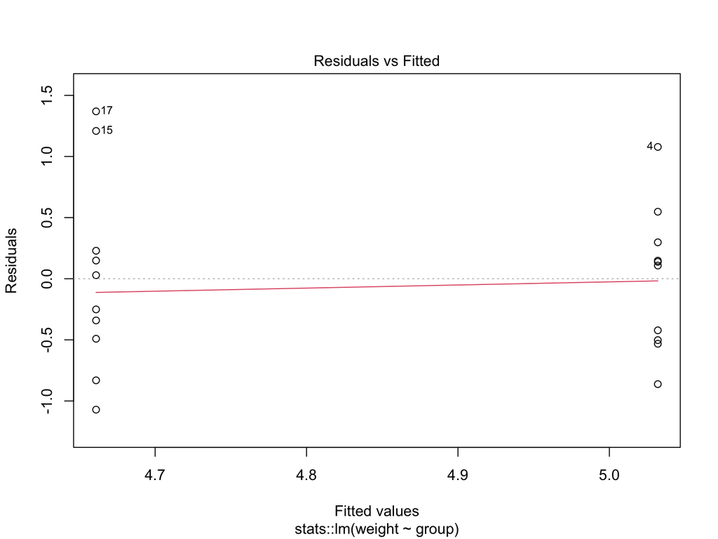

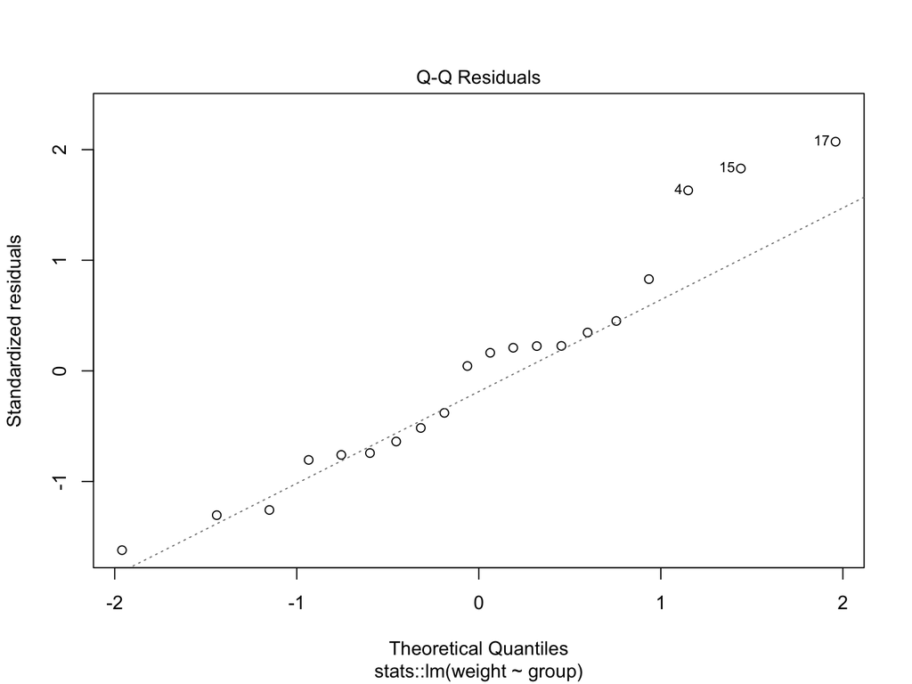

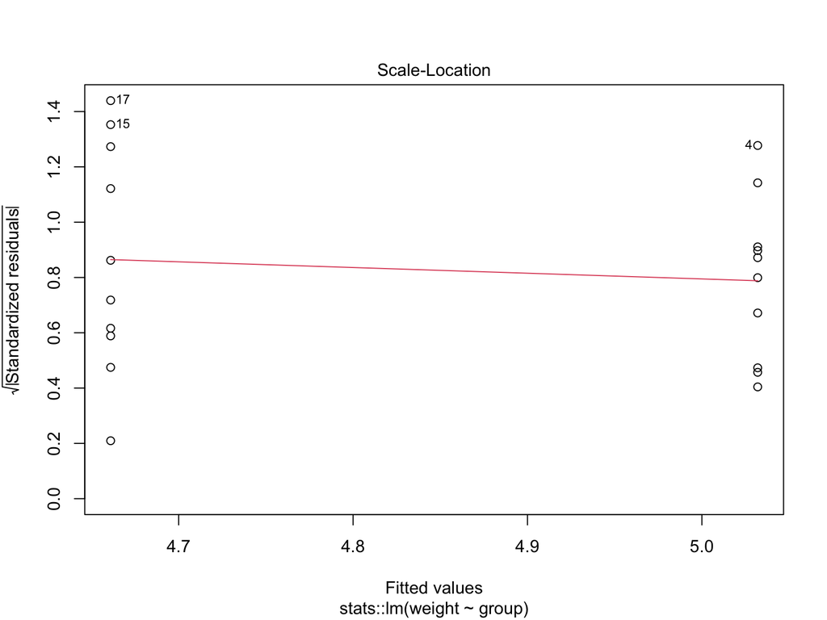

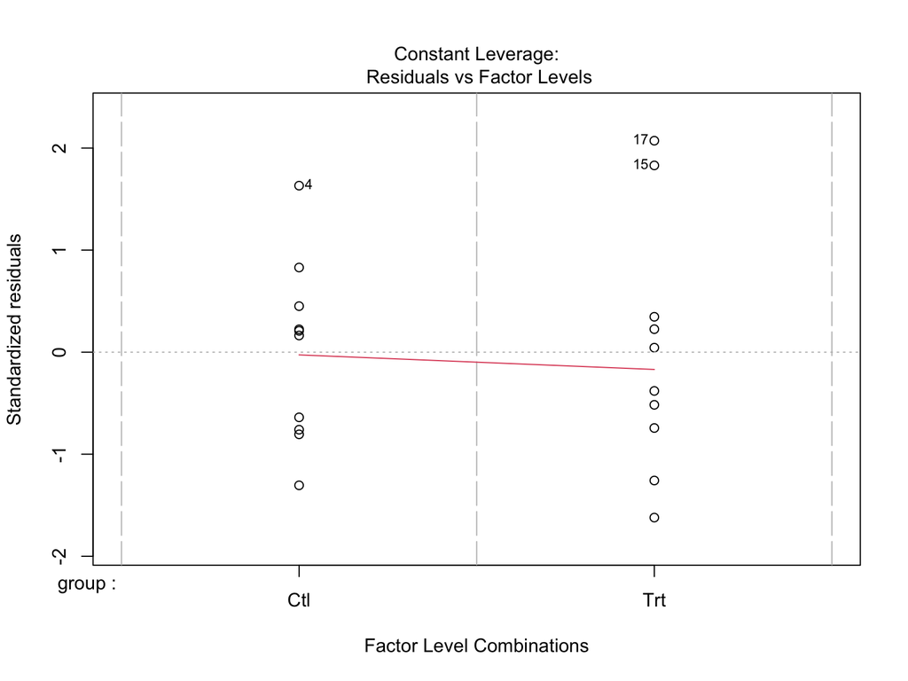

```r
plot(lm_D9)
```

But this isn’t the normal behavior of a list…

```r
plot(example_list)
```

```
## Error in `xy.coords()`:
## ! 'x' is a list, but does not have components 'x' and 'y'
```

Somehow, when we run `summary()` on `lm_D9`, we can an informative summary.

```r
summary(lm_D9)
```

```
##
## Call:
## stats::lm(formula = weight ~ group)
##
## Residuals:
##     Min      1Q  Median      3Q     Max
## -1.0710 -0.4938  0.0685  0.2462  1.3690
##
## Coefficients:
##             Estimate Std. Error t value Pr(>|t|)
## (Intercept)   5.0320     0.2202  22.850 9.55e-15 ***
## groupTrt     -0.3710     0.3114  -1.191    0.249
## ---
## Signif. codes:  0 '***' 0.001 '**' 0.01 '*' 0.05 '.' 0.1 ' ' 1
##
## Residual standard error: 0.6964 on 18 degrees of freedom
## Multiple R-squared:  0.07308,    Adjusted R-squared:  0.02158
## F-statistic: 1.419 on 1 and 18 DF,  p-value: 0.249
```

But this isn’t the normal behavior of a list…

```r
summary(example_list)
```

```
##   Length Class  Mode
## a 10     -none- numeric
## b  1     -none- character
```

What is going on? How does this happen?